# 10. Clustering Redux, EDA

## Load the Data

For today’s notes we will work with one of the data sets from Project 2, specifically the reviews of Music CDs.

```r
docs <- read_csv("../data/amazon_cds.csv.bz2")
anno <- read_csv("../data/amazon_cds_token.csv.bz2")
```

We are going to briefly redescribe the two clutsering algorithms from last time and show how they can be used in data analysis.

## Clustering (Again)

I was still unable to find the original visualisation of K-Means I mentioned last week, but here is a good interactive visualisation to describe the process of iteratively choosing centroids and cluster assignments:

- [visualisation of kmeans](https://www.naftaliharris.com/blog/visualizing-k-means-clustering/)

Let’s compute the K-means algorithms using nouns and verbs in two dimensions.

```r
df <- anno %>%
  filter(upos %in% c("NOUN", "VERB")) %>%
  dsst_kmeans(docs, doc_var = "label", n_dims = 2,
                  n_clusters = 5L, output_type="df")
```

And plot the results, just as before. You can see a clear structure to the data in the clustering output:

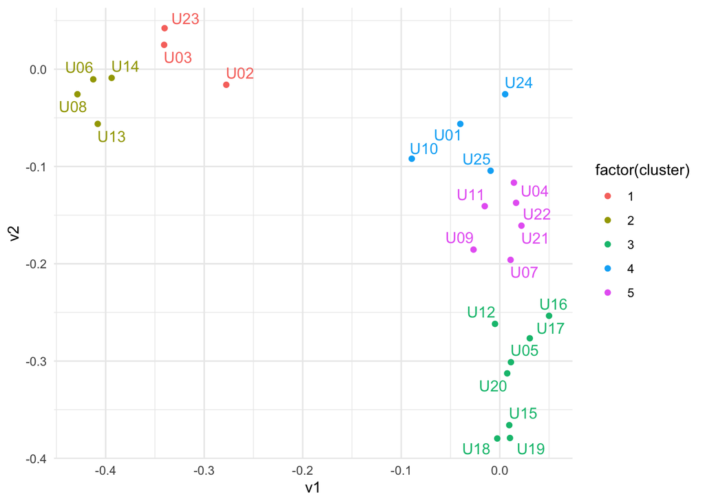

```r
library(ggrepel)
ggplot(df, aes(v1, v2)) +
  geom_point(aes(color = factor(cluster))) +
  geom_text_repel(aes(color = factor(cluster), label = label), show.legend = FALSE)
```

Last time I had used a very different approach to computing the hierarchical clustering. It was not wrong per say, but worked in a way that was hard to compare to the K-means clustering. I have updated the code and the results should now align better with those from the K-means code:

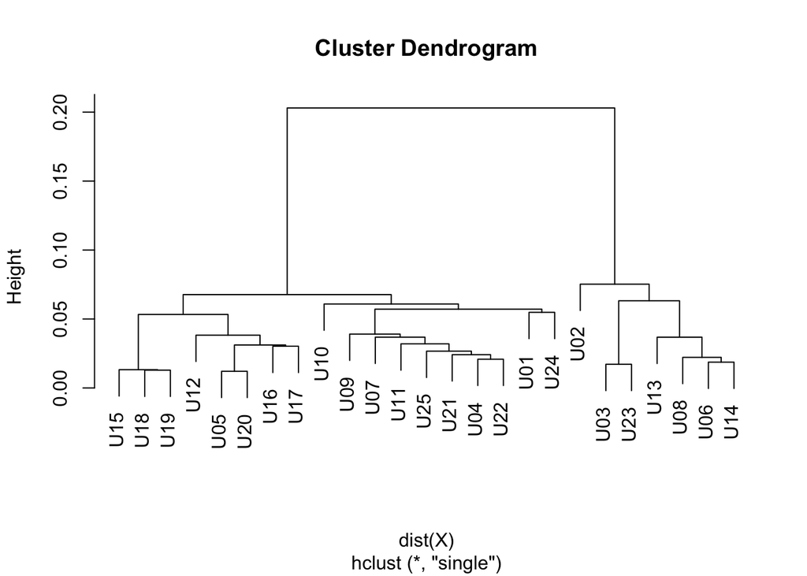

```r
model <- anno %>%
  filter(upos %in% c("NOUN", "VERB")) %>%
  dsst_hclust(docs, doc_var = "label")

dsst_hclust_plot(model)
```

Can you see the correspondence between the two techniques now?

## Working with the Clusters

I wanted to show a few things you can do with the cluster assignments. In general, I use them as artificially constructed labels for the documents. For example, we can see the average length of each cluster’s documents:

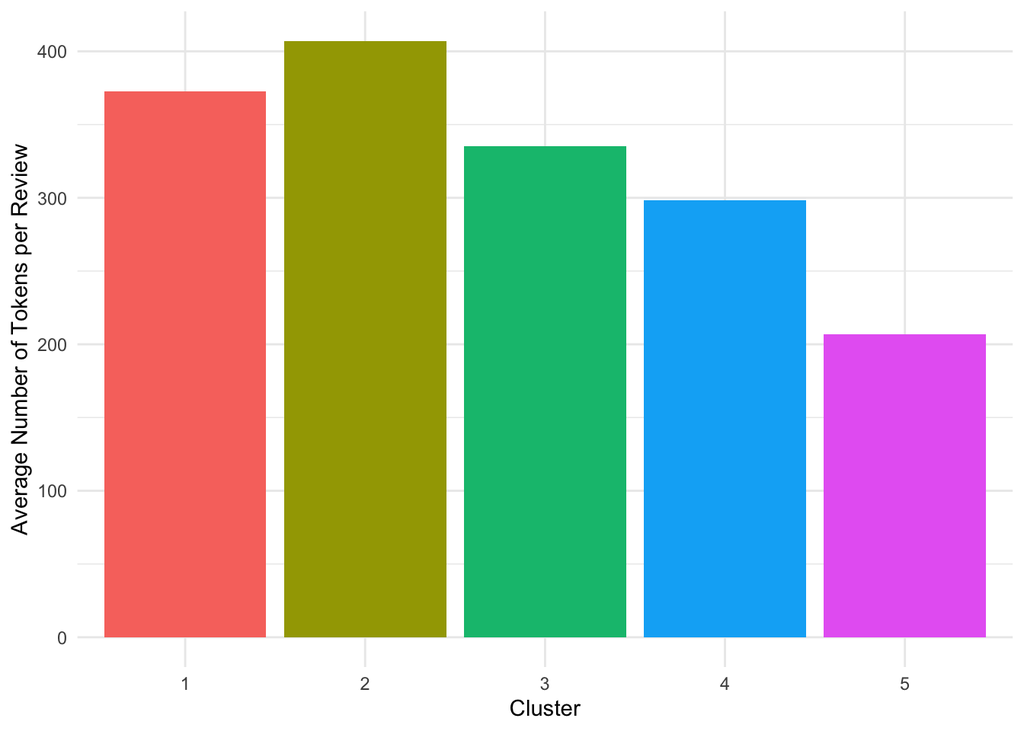

```r
anno %>%
  group_by(doc_id) %>%
  summarise(n = n()) %>%
  left_join(docs, by = "doc_id") %>%
  left_join(df, by = "label") %>%
  group_by(cluster) %>%
  summarise(avg_tokens = mean(n)) %>%
  ggplot(aes(factor(cluster), avg_tokens)) +
    geom_col(aes(fill = factor(cluster)), show.legend = FALSE) +
    labs(x = "Cluster", y = "Average Number of Tokens per Review")
```

Or compute the G-score metrics:

```r
anno %>%
  filter(upos %in% c("NOUN", "VERB")) %>%
  dsst_metrics(left_join(docs, df, by = "label"),
               label_var = "cluster", higher_only = TRUE)
```

```
## [[1]]
## # A tibble: 5,262 × 7
##    label token       count expected count_word gscore  chi2
##    <dbl> <chr>       <int>    <dbl>      <int>  <dbl> <dbl>
##  1     1 recording     448   221.         1535  223.   275.
##  2     1 account        87    20.0         139  170.   262.
##  3     1 voice         274   128.          888  157.   196.
##  4     1 performance   329   166.         1157  152.   186.
##  5     1 role           93    27.9         194  124.   177.
##  6     1 soprano        77    20.6         143  122.   181.
##  7     1 aria           44     8.34         58  111.   178.
##  8     1 acquire        42     8.63         60   95.2  151.
##  9     1 cast           69    20.9         145   90.6  130.
## 10     1 opera         103    41.3         287   82.0  108.
## # … with 5,252 more rows
##
## [[2]]
## # A tibble: 4,497 × 7
##    label token       count expected count_word gscore  chi2
##    <dbl> <chr>       <int>    <dbl>      <int>  <dbl> <dbl>
##  1     2 work          991    384.        1939   951. 1208.
##  2     2 movement      424    121.         609   710.  955.
##  3     2 performance   609    229.        1157   618.  790.
##  4     2 composer      321     87.9        444   572.  772.
##  5     2 symphony      223     59.8        302   411.  556.
##  6     2 orchestra     232     70.7        357   345.  460.
##  7     2 conductor     199     56.6        286   332.  447.
##  8     2 piano         335    128.         646   329.  419.
##  9     2 recording     609    304.        1535   322.  385.
## 10     2 pianist       175     48.9        247   301.  406.
## # … with 4,487 more rows
##
## [[3]]
## # A tibble: 5,293 × 7
##    label token  count expected count_word gscore  chi2
##    <dbl> <chr>  <int>    <dbl>      <int>  <dbl> <dbl>
##  1     3 funk     431    164.         446   745.  687.
##  2     3 band    1033    550.        1493   646.  676.
##  3     3 rock     808    401.        1089   631.  656.
##  4     3 guitar   655    307.         834   608.  625.
```

[output cut: 24 more lines]

```
## [[5]]
## # A tibble: 2,268 × 7
##    label token       count expected count_word gscore  chi2
##    <dbl> <chr>       <int>    <dbl>      <int>  <dbl> <dbl>
##  1     5 song         1426    669.        4133   842. 1041.
##  2     5 number        386    114.         703   553.  780.
##  3     5 hit           532    208.        1288   462.  603.
##  4     5 sing          411    146.         901   430.  578.
##  5     5 cd            475    207.        1279   329.  416.
##  6     5 love          465    220.        1358   266.  328.
##  7     5 perform       221     73.1        452   261.  357.
##  8     5 arrangement   191     60.8        376   240.  333.
##  9     5 artwork        83     15.2         94   239.  361.
## 10     5 fan           288    123.         758   209.  267.
## # … with 2,258 more rows
```

Or even build a predictive model:

```r
model <- anno %>%
  filter(upos %in% c("NOUN", "VERB")) %>%
  dsst_enet_build(left_join(docs, df, by = "label"),
                  label_var = "cluster")

dsst_erate(model)
```

```
## # A tibble: 1 × 2
##    train valid
##    <dbl> <dbl>
## 1 0.0714  0.16
```

Does the confusion matrix show a similar structure to that of the heirarchical clustering?

```r
dsst_confusion_matrix(model)
```

```
##
##       1   2   3   4   5
##   1 228  70  12   4  61
##   2  36 407  16   8  33
##   3   0   6 883  13  98
##   4   0   0  35 427  38
##   5   1   1  53  15 680
```

You can even do the clustering on all of the documents and analyse those.

```r
df <- anno %>%
  dsst_kmeans(docs, n_dims = 2L, n_clusters = 20L, output_type="df")
```

Do the clusters of the documents correspond to particular users?

```r
df %>%
  left_join(docs, by = "doc_id") %>%
  select(cluster, label) %>%
  table()
```

```
##        label
## cluster U01 U02 U03 U04 U05 U06 U07 U08 U09 U10 U11 U12 U13 U14 U15 U16 U17
##      1    2   7   6   7  11   6  28   0   1  11   5   2   4   1  21   4   2
##      2    0   6  60   0   0  27   1   5   0   1   0   2  19  14   0   0   0
##      3    0   0   0   0   0   0   0   0   0   0   0   0   0   0   0   0   0
##      4   11   1   5   0   2   2  11   0  17  10   0  50   1   1  82  14  22
##      5    1   1  22   2   0  10   5   0   1   2   0  10   8   1  19   0  11
##      6    2  77  30   3   0  95   2  40   0   9  15   4  46  84   0   0   2
##      7    4   1   0   5  65   0  34   0   4   5   0   3   0   0  36   5   3
##      8    0   2  15   0   0   7   0 109   0   0   0   1  61   9   0   0   0
##      9    9   0   0   1  77   0  32   0  29   6   0   4   0   0  16   5   3
##      10  53   0   0   0  18   0  25   0  47   2   0  14   0   0   4  51   9
##      11   0   4   0  23  12   0   9   0   2  13   3   0   0   0   0   0   0
##      12  19   0  16   0   0   2   0   0   9   0   0  55   3   0  14  21  32
##      13   1  22   0  64  36   2  37   1   1  39  49   0   0   0   0   0   0
```

[output cut: 29 more lines]

And are there any patterns related to the length of each of the clusters?

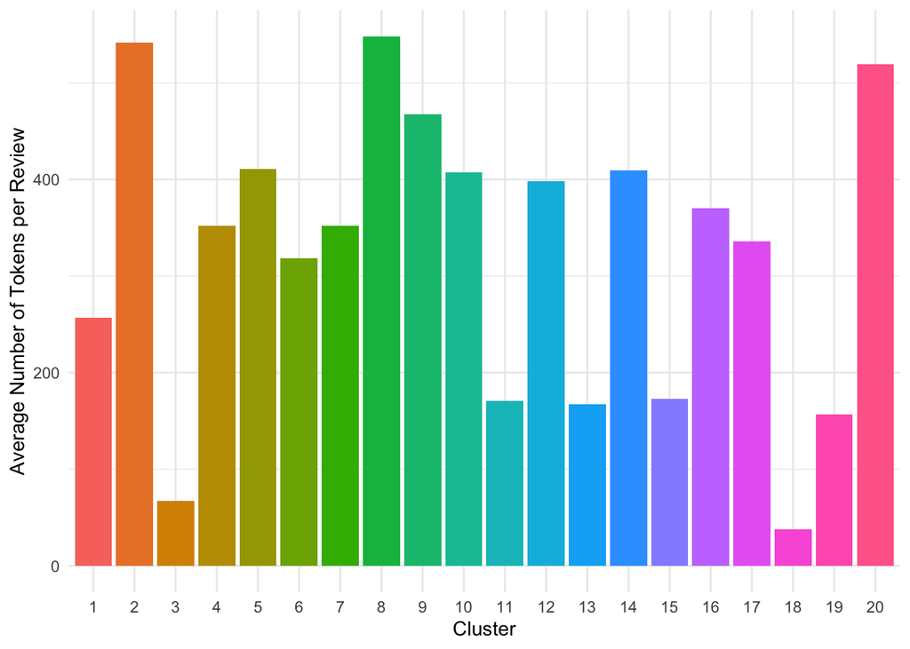

```r
anno %>%
  group_by(doc_id) %>%
  summarise(n = n()) %>%
  left_join(df, by = "doc_id") %>%
  group_by(cluster) %>%
  summarise(avg_tokens = mean(n)) %>%
  ggplot(aes(factor(cluster), avg_tokens)) +
    geom_col(aes(fill = factor(cluster)), show.legend = FALSE) +
    labs(x = "Cluster", y = "Average Number of Tokens per Review")
```